# Mapping distribution and diversity using high and low def countries/regions

Thomas L.P. Couvreur

Last compiled on 21 septembre, 2021

> Here we shall learn how to:  
> - import and plot different type of maps, either at country or regional levels  
> - import distribution data and plot them onto the maps

# 1 Initial things to do

## 1.1 Set working directory

This is your own working directory, on your PC, update path below

```
setwd("C:/Users/couvreur/Documents/R/mada_annon_R/")
```

## 1.2 Load needed libraries

**optional**: Install them first if not done already

```
install.packages(c("ConR", "devtools", "mapproj", "maps", "rnaturalearthdata",
                   "rgbif", "raster", "rnaturalearth", "tidyverse", "maptools", "ggmap"))
```

Load the libraries

```
library(ggmap)
library(ggplot2)
library(sf)
library(dplyr)
library(ggplot2)
library(scico)
library(rnaturalearth)
library(purrr)
library(smoothr)
library(rworldxtra)
library(tidyr)
```

# 2 Plot country or regional maps

Select what country you want here:

```r
country = "Madagascar"
```

Or select the region you want, using coordinates:

```r
xlat = c(40, 60)
ylong = c(-26, -12)
```

We can plot maps at two levels of precision in terms of countries: Low and high.  
Maps are plotted using `ggplot2`, see after.

## 2.1 Low precision maps

1. Import a lower definition map from `rnaturalearth` package

```r
worldMap <- ne_countries(scale = "medium", type = "countries", returnclass = "sf")
```

2. Filter the country you want, creates a *NCpoly_low* object

```r
CNpoly_low <- worldMap %>% filter(sovereignt == country)
```

3. Simple plot of the map using *plot()* function

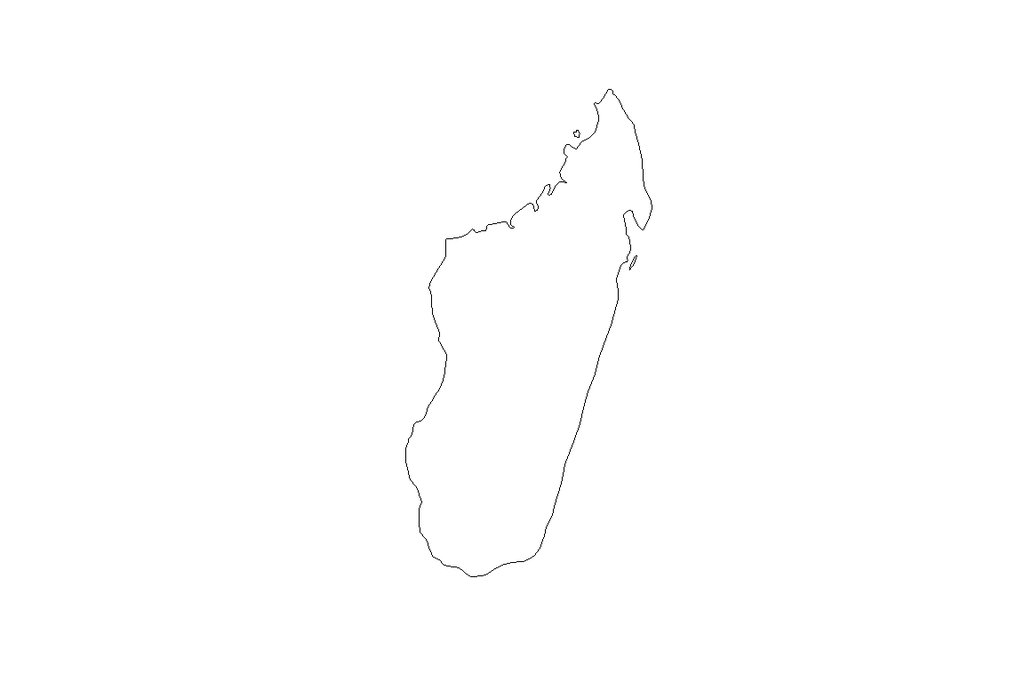

```r
plot(CNpoly_low$geometry)
```

## 2.2 High presicion maps

1. Import a higher definition map from `rworldxtra` package

```r
data(countriesHigh)
CNhigh = st_as_sf(countriesHigh)
```

2. Filter the country you want, creates a *NCpoly* object

```r
CNpoly <- CNhigh %>% filter(ADMIN == country)
```

## 2.3 Plot *country* map with `ggplot2`

Plot the high definition country filtered above.

Set limits around country, creates a *limsCN* object

```r
limsCN <- st_buffer(CNpoly, dist = 0.7) %>% st_bbox
```

Plot map with different options that can be changed.

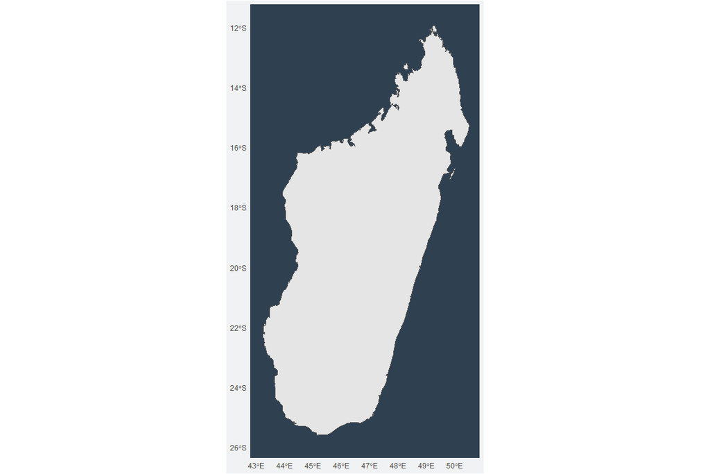

```r
divpolPlot <-
  ggplot() +
  geom_sf(data = CNpoly) +
  coord_sf(
    xlim = c(limsCN["xmin"], limsCN["xmax"]),
    ylim = c(limsCN["ymin"], limsCN["ymax"])
  ) +
  theme(
    plot.background = element_rect(fill = "#f1f2f3"),
    panel.background = element_rect(fill = "#2F4051"),
    panel.grid = element_blank(),
    line = element_blank(),
    rect = element_blank()
  )
divpolPlot
```

## 2.4 Plot *regional* map with `ggplot2`

Here we shall indicate a region using coordinates, rather than filtering for a country.  
We use the *CNhigh* object.  
Here coordinates for Madagascar. CAREFULL: *xlat* and *ylong* are defined above.

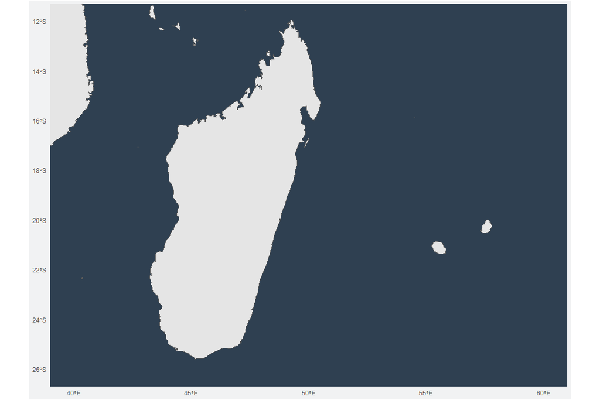

```r
divpolPlot <-
  ggplot() +
  geom_sf(data = CNhigh) +
  coord_sf(
    xlim = xlat,
    ylim = ylong
  ) +
  theme(
    plot.background = element_rect(fill = "#f1f2f3"),
    panel.background = element_rect(fill = "#2F4051"),
    panel.grid = element_blank(),
    line = element_blank(),
    rect = element_blank()
  )
divpolPlot
```

## 2.5 Add some climatic data to the plots

Here we shall download data from WorldClim and plot it with the map.

### 2.5.1 Download or import climatic data from *WorldClim*

If already downloaded and strored on your PC locally:

```
 climate=getData('worldclim', var='bio',res=2.5, download=FALSE)
```

Otheriwe (this step can take some time (ca. 123 Mb of data)):

```r
climate=getData('worldclim', var='bio',res=2.5)
```

### 2.5.2 Crop to region of interest

```r
climate <- crop(climate,extent(40, 60,-26, -12))
```

### 2.5.3 Raster the layer you want, here *bio12*

```r
raster <- climate$bio12
```

### 2.5.4 Clean na values

```r
rasdf <- as.data.frame(raster,xy=TRUE)%>%drop_na()
```

Now we have a rasterized layer of climate data (*bio12*) we can add to ggplot, see below.

# 3 Plot species distribution data on map

## 3.1 Import original raw occurence dataset

Update paths and file name to your own

```r
df <- read.csv("data/occs_cleaned_medrged_WAG_TAN_MO_P_03092021.csv", header = TRUE, sep = ";", stringsAsFactors = FALSE)
```

Our raw database contains **2927** unique records representing **17** genera and **110** species.

## 3.2 Plot distribution data on *regional* map **without** climatic data

We have now added a *geom_point* argument to the ggplot script:

`geom_point(data=df, aes(x=ddlong, y=ddlat), bg = rgb(red = 1, green = 0, blue = 0, alpha = 0.5), col = "black", pch = 21, cex=2) +`

Color and shape of points can be changed in the script. In our file, the columns *ddlat* and *ddlong* indicate the coordinates.

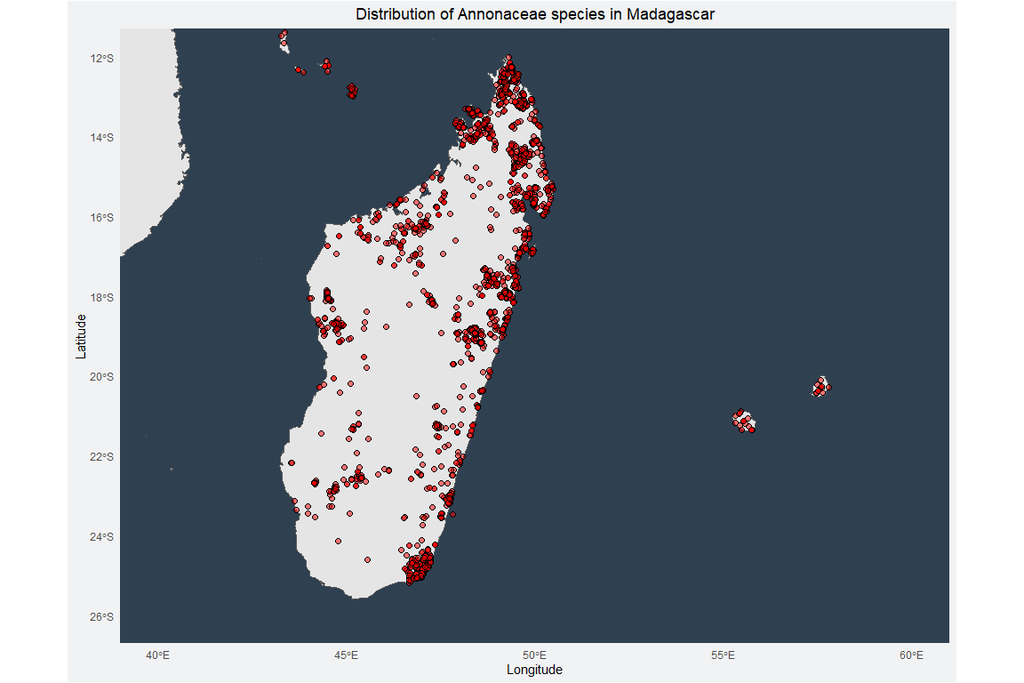

```r
divpolPlot <-
ggplot() +
  geom_sf(data = CNhigh) +
  geom_point(data=df, aes(x=ddlong, y=ddlat), bg = rgb(red = 1, green = 0, blue = 0, alpha = 0.5), col = "black", pch = 21, cex=2) +
  coord_sf(
    xlim = xlat,
    ylim = ylong
  ) +
  theme(
    plot.background = element_rect(fill = "#f1f2f3"),
    panel.background = element_rect(fill = "#2F4051"),
    panel.grid = element_blank(),
    line = element_blank(),
    rect = element_blank()
  )
divpolPlot + ggtitle("Distribution of Annonaceae species in Madagascar") + theme(plot.title = element_text(hjust = 0.5)) + xlab("Longitude") + ylab("Latitude")
```

## 3.3 Plot distribution data on *regional* map **with** climatic data

This ggplot script is different than the one above as it adds the climate data.

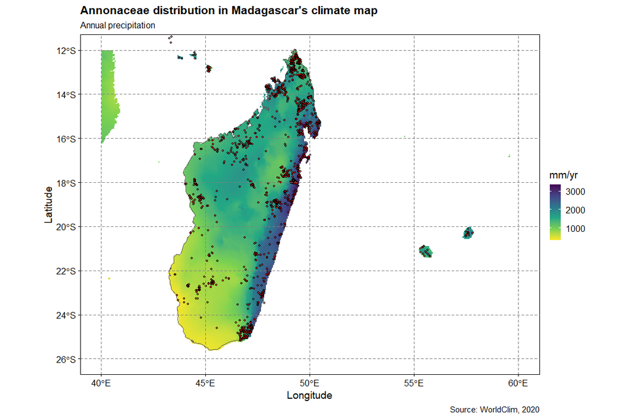

```r
ggplot()+
  geom_raster(aes(x=x,y=y,fill=bio12),data=rasdf)+
  geom_sf(fill='transparent',data=CNpoly)+
  scale_fill_viridis_c('mm/yr',direction = -1)+
  coord_sf(expand=c(0,0))+
  geom_point(data=df, aes(x=ddlong, y=ddlat), bg = rgb(red = 1, green = 0, blue = 0, alpha = 0.5), col = "black", pch = 21, cex=1) +
  coord_sf(
    xlim = xlat,
    ylim = ylong
  ) +
  labs(x='Longitude',y='Latitude',
       title="Annonaceae distribution in Madagascar's climate map",
       subtitle='Annual precipitation',
       caption='Source: WorldClim, 2020')+
  cowplot::theme_cowplot()+
  theme(panel.grid.major = element_line(color = gray(.5),
                                        linetype = 'dashed',
                                        size = 0.5),
        panel.grid.minor = element_blank(),
        panel.background = element_rect(fill=NA,color = 'black'),
        panel.ontop = TRUE)
```